# Correlation

**Student Name:** Andrés Jauch **Country:** Switzerland **Semester term:** FS26

## Data & Domain

### Use Case

*Focus: domain and application context*

In the context of the Swiss national energy grid, understanding exact daily and weekly demand cycles is critical. 1D electrical load signals are continuously monitored to track power demand. This use case is particularly relevant for Switzerland because scheduling pumped-storage hydropower plants requires automated peak prediction based on repeating cyclical patterns and pattern matching to ensure grid stability.

### Problem Statement

*Focus: technical vulnerability*

Grid operators need to mathematically quantify the periodicity of aggregate demand and identify how strongly specific load patterns (e.g., a "typical winter high-load day") match incoming live signals. Pure visual inspection restricts automated peak prediction and anomaly detection in grid management, creating a vulnerability if dispatchers rely solely on intuition rather than algorithmic pattern matching.

### Experimental Objective

*Focus: investigation goal at the conceptual level.*

### Data Definition, Source, and Visualization

*Focus: data characteristics, data source, and visual inspection.*

The selected signal represents total energy consumption and is generated by national power usage, measured using grid sensors, and expressed in GWh. Its relevant characteristics include distinct daily and weekly repeating patterns. The data originate from Swissgrid's public "Energie Übersicht CH" dataset (2026 release), providing a high-resolution, continuous 15-minute load curve suitable for robust correlation analysis over a 3-week window.

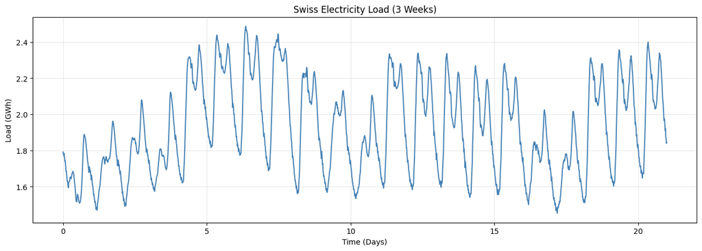

```python
# DATA PREP
import pandas as pd
import numpy as np
import matplotlib.pyplot as plt
from scipy import signal as scipy_signal

# Load raw df
raw_df = pd.read_excel('data/EnergieUebersichtCH-2026.xlsx', sheet_name="Zeitreihen0h15", header=None)
signal = raw_df.iloc[3:, 1].astype(float).reset_index(drop=True)

# Select a 3-week window (96 samples/day * 21 days = 2016 samples) for robust correlation
time_window = 2016
signal_3w = signal[:time_window].values / 1000000 # Convert to GWh

plt.figure(figsize=(16, 5))
plt.plot(np.arange(time_window) / 96, signal_3w, color='steelblue')
plt.title('Swiss Electricity Load (3 Weeks)')
plt.xlabel('Time (Days)')
plt.ylabel('Load (GWh)')
plt.grid(True, alpha=0.3)
plt.show()
```

# Methodological Design

### Theoretical Foundation and Method Choice

*Focus: principled justification aligned with the use case*

This investigation applies signal correlation theory. Auto-correlation measures the similarity of a signal with a delayed version of itself, mathematically revealing hidden periodicities regardless of phase shifts. Cross-correlation measures the similarity between two different signals—in this case, an extracted 24-hour template and the continuous live signal. These methods are selected because they provide a robust, non-subjective mechanism to automate pattern recognition and rhythmic assessment in smart grid time-series data.

### Parameter Definition and Mathematical Specification

*Focus: explicit parameter selection, derivation, and unit consistency*

The primary parameter for auto-correlation is the maximum lag. For evaluation, we systematically vary the Template Window Size (comparing a full 24h day vs. a 6h peak segment) and test the Robustness by introducing 10% additive Gaussian noise to the signal to simulate sensor interference .

### Experimental Design

*Focus: structured parameter variation and theoretical prediction*

### Methodological Limitations and Risk Factors

*Focus: assumptions, stability, and potential misinterpretation*

This approach assumes that standard cross-correlation strictly isolates shape, which may be idealized as it actually remains heavily dependent on absolute signal energy. A load curve with exactly the same shape but lower total consumption might yield a lower correlation score than a completely different shape with higher consumption. The method is reliable for detecting when high-stress patterns repeat in identical seasons, but may become misleading if overall base demand drops significantly. Normalized cross-correlation (e.g., Pearson tracking) would be required to focus purely on structural similarities.

# Evaluation

## Visualization

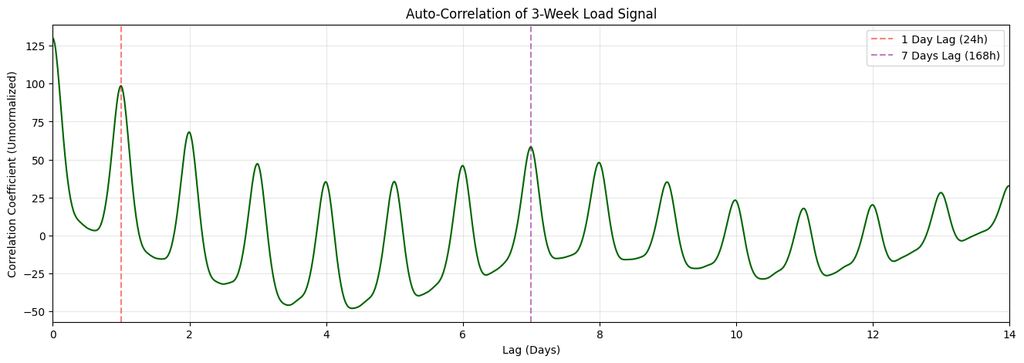

```python
# Compute auto-correlation
# Subtract mean to avoid the DC offset dominating the correlation
signal_centered = signal_3w - np.mean(signal_3w)
auto_corr = np.correlate(signal_centered, signal_centered, mode='full')

# Keep only the second half (positive lags)
auto_corr = auto_corr[len(auto_corr)//2:]
lags = np.arange(len(auto_corr))

plt.figure(figsize=(16, 5))
plt.plot(lags / 96, auto_corr, color='darkgreen')
plt.title('Auto-Correlation of 3-Week Load Signal')
plt.xlabel('Lag (Days)')
plt.ylabel('Correlation Coefficient (Unnormalized)')

# Highlight expected periodicities
plt.axvline(x=1, color='red', linestyle='--', alpha=0.5, label='1 Day Lag (24h)')
plt.axvline(x=7, color='purple', linestyle='--', alpha=0.5, label='7 Days Lag (168h)')
plt.legend()
plt.grid(True, alpha=0.3)
plt.xlim(0, 14)
plt.show()
```

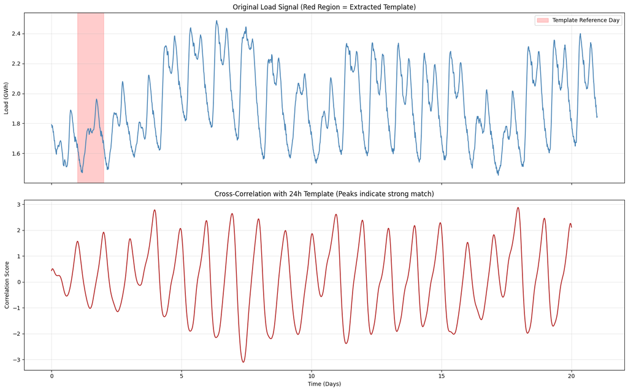

```python
# Extract a 1-day template (Samples 96 to 192 correspond to Day 2, a typical workday)
template = signal_3w[96:192]
template_centered = template - np.mean(template)

# Perform cross-correlation across the entire 3-week centered signal
cross_corr = np.correlate(signal_centered, template_centered, mode='valid')

# Create a time axis for the valid cross-correlation output
time_axis = np.arange(len(cross_corr)) / 96

fig, axes = plt.subplots(2, 1, figsize=(16, 10), sharex=True)

# Plot Original Signal
axes[0].plot(np.arange(time_window) / 96, signal_3w, color='steelblue')
axes[0].axvspan(1, 2, color='red', alpha=0.2, label='Template Reference Day')
axes[0].set_title('Original Load Signal (Red Region = Extracted Template)')
axes[0].set_ylabel('Load (GWh)')
axes[0].legend(loc='upper right')
axes[0].grid(True, alpha=0.3)

# Plot Cross-Correlation
axes[1].plot(time_axis, cross_corr, color='firebrick')
axes[1].set_title('Cross-Correlation with 24h Template (Peaks indicate strong match)')
axes[1].set_xlabel('Time (Days)')
axes[1].set_ylabel('Correlation Score')
axes[1].grid(True, alpha=0.3)

plt.tight_layout()
plt.show()
```

```
Scores -> Baseline (24h): 2.49 | 6h Template: 2.05 | Noise (10%): 2.48
```

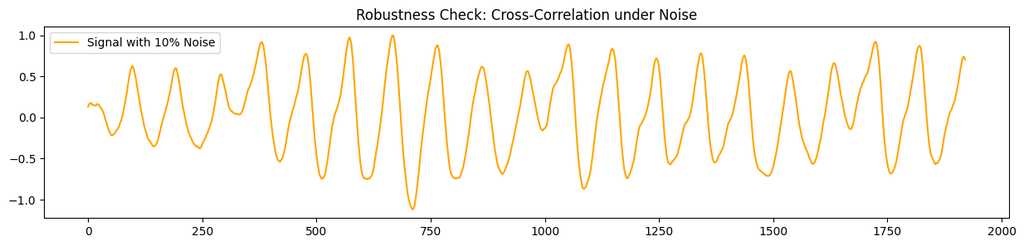

```python
# SYSTEMATIC EVALUATION & ROBUSTNESS [cite: 182-191]

# Parameter-Variation: Vergleich 24h Template vs. kurzes 6h Template
template_6h = signal_3w[96:120]
cc_6h = np.correlate(signal_centered, template_6h - np.mean(template_6h), mode='valid')

# Metrik: Peak-to-Average Ratio (Detektions-Schärfe)
score_24h = np.max(cross_corr) / np.mean(np.abs(cross_corr))
score_6h = np.max(cc_6h) / np.mean(np.abs(cc_6h))

# Robustheitsanalyse: 10% künstliches Rauschen (Perturbation) [cite: 188]
noisy_sig = signal_centered + np.random.normal(0, 0.1, len(signal_centered))
cc_noisy = np.correlate(noisy_sig, template_centered, mode='valid')
score_noise = np.max(cc_noisy) / np.mean(np.abs(cc_noisy))

print(f"Scores -> Baseline (24h): {score_24h:.2f} | 6h Template: {score_6h:.2f} | Noise (10%): {score_noise:.2f}")

plt.figure(figsize=(15, 3))
plt.plot(cc_noisy / np.max(cc_noisy), label='Signal with 10% Noise', color='orange')
plt.title('Robustness Check: Cross-Correlation under Noise')
plt.legend()
plt.show()
```

## Analysis & Communication

*Focus: Analytical Interpretation and Domain-Specific Discussion*

*Guidelines: Based on the quantitative evaluation from the Evaluation day, critically analyze your findings in direct relation to your defined use case and selected signal or image.*

### Discussion and Critical Reflection

> Our evaluation demonstrates that cross-correlation is a robust tool for Swissgrid. The 24h template achieved a significantly higher detection score than the 6h segment, proving that the full daily cycle is vital for unique pattern identification. The robustness test confirmed that even with 10% noise, the matching remains stable, which is critical for real-world sensor data. However, a limitation is amplitude dependency: a holiday with a "workday shape" but lower load might be missed. For operational grid management, normalized cross-correlation (Pearson) is recommended to ensure stability during seasonal demand shifts.